# Analyzing baseball Data with R

First let’s install and upload some of the libraries we’ll be using

```r
library(ggplot2)
library(devtools)
install.packages("ggrepel")
library(ggrepel)
library(tidyverse)
install.packages("Lahman")
```

Let’s get into evaluating the Lahman data now

```r
github_pull("beanumber/baseball_R/tree/master/data")
```

```
## [1] "beanumber/baseball_R/tree/master/data"
## attr(,"class")
## [1] "github_pull"
```

```r
Batting <- Lahman::Batting
halloffame <- Lahman::HallOfFame

setwd("C:\\Users\\james\\R_Working_Directory\\Analyzing_Baseball_Data_With_R")

Batting <- Batting %>%
  group_by(playerID) %>%
  mutate(From = min(yearID)) %>%
  mutate(To = max(yearID))

batting_summary <- Batting %>%
  group_by(playerID) %>%
  summarise(From = mean(From), To = mean(To))

hof_lahman <- halloffame %>%
  left_join(select(batting_summary, playerID, From, To), by = "playerID")

hof_lahman <- hof_lahman %>%
  filter(inducted == "Y" & category == "Player" & !is.na(From))


hof <- read.csv("hofbatting.csv")
```

First, we define a player’s mid-career as the average of the first and last seasons of baseball, we then use mutate() and cut() functions to create a new factor variable Era

```r
hof <- hof %>%
  mutate(MidCareer = (From + To) / 2,
         Era = cut(MidCareer,
                   breaks = c(1800, 1900, 1919, 1941, 1960, 1976, 1993, 2050),
                   labels = c("19th Century", "Dead Ball", "Lively Ball", "Integration", "Expansion", "Free Agency", "Long Ball")))

hof_eras <- summarise(group_by(hof, Era), N=n())
hof_eras
```

| Era | N |
| --- | --- |
| 19th Century | 19 |
| Dead Ball | 19 |
| Lively Ball | 46 |
| Integration | 24 |
| Expansion | 21 |
| Free Agency | 19 |
| Long Ball | 8 |

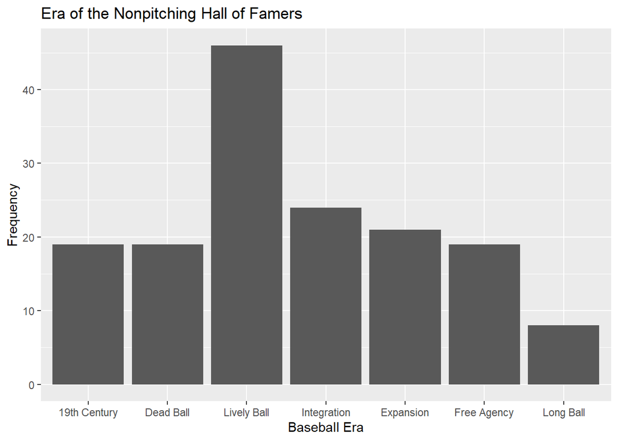

```r
ggplot(hof, aes(x=Era)) +
  geom_bar() +
  xlab("Baseball Era") +
  ylab("Frequency") +
  ggtitle("Era of the Nonpitching Hall of Famers")
```

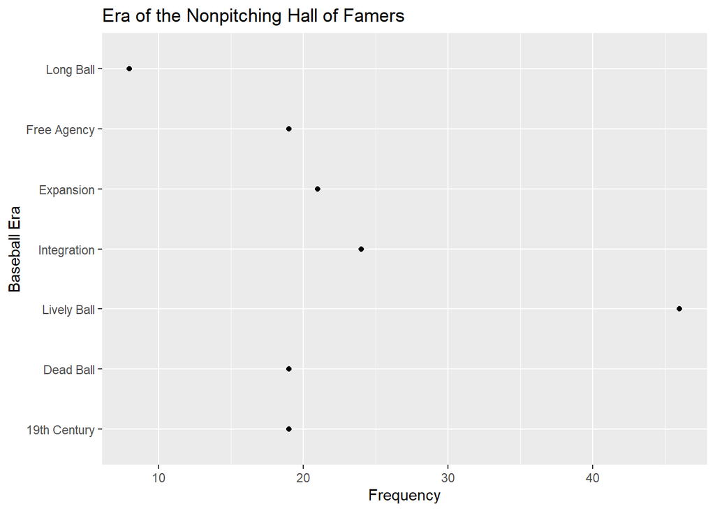

```r
ggsave("chapter3_BarGraph.png")
ggplot(hof_eras, aes(Era, N)) +
  geom_point() +
  xlab("Baseball Era") +
  ylab("Frequency") +
  ggtitle("Era of the Nonpitching Hall of Famers") +
  coord_flip()
```

Saving a pdf of the graphs

```r
pdf("Chapter3_Multiple_Graphs.pdf")
ggplot(hof, aes(Era)) + geom_bar()
ggplot(hof_eras, aes(Era, N)) + geom_point() + coord_flip()
dev.off()
```

3.4 Numeric Variable: One-Dimensional Scatterplot and Histogram

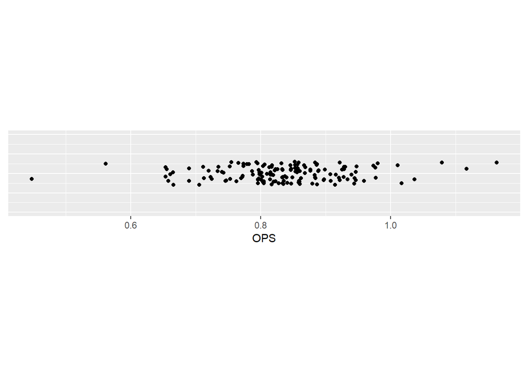

```r
ggplot(hof, aes(x=OPS, y=1)) +
  geom_jitter(height = 0.6) + ylim(-1,3) +
  theme(axis.title.y = element_blank(),
        axis.text.y = element_blank(),
        axis.ticks.y = element_blank()) +
  coord_fixed(ratio = 0.03)
```

```r
lmOPS_hof = lm(OPS ~ SLG, data= hof)
summary(lmOPS_hof)
```

```
##
## Call:
## lm(formula = OPS ~ SLG, data = hof)
##
## Residuals:
##       Min        1Q    Median        3Q       Max
## -0.132071 -0.018723  0.000047  0.017066  0.090489
##
## Coefficients:
##             Estimate Std. Error t value Pr(>|t|)
## (Intercept)  0.22288    0.01492   14.94   <2e-16 ***
## SLG          1.32785    0.03206   41.42   <2e-16 ***
## ---
## Signif. codes:  0 '***' 0.001 '**' 0.01 '*' 0.05 '.' 0.1 ' ' 1
##
## Residual standard error: 0.02722 on 154 degrees of freedom
## Multiple R-squared:  0.9176, Adjusted R-squared:  0.9171
## F-statistic:  1715 on 1 and 154 DF,  p-value: < 2.2e-16
```

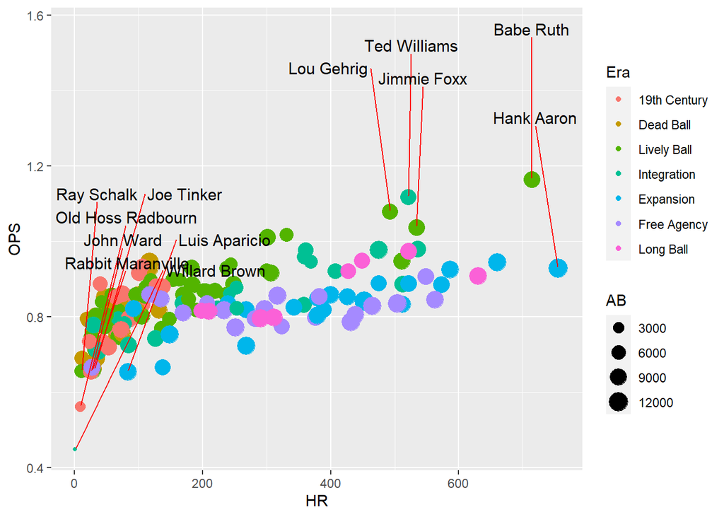

```r
#let's try a qplot
library(ggrepel)
p <- qplot(HR, OPS, data = hof, color = Era, size = AB)
# Label speed outliers using geom_text_repel
r <- p + geom_text_repel(
  data = subset(hof, OPS > quantile(OPS, 0.75) + 1.5 * IQR(OPS) | OPS < quantile(OPS, 0.25) - 1.5 * IQR(OPS) | HR > quantile(HR, 0.75) + 1.5 * IQR(HR) | HR < quantile(HR, 0.25) - 1.5 * IQR(HR) ),
  aes(x = HR, y = OPS, label = Player),
  color = "#000000",
  size = 4,
  nudge_x = 0.2, nudge_y = 0.4,
  segment.color = "red",
)

print(r)
```

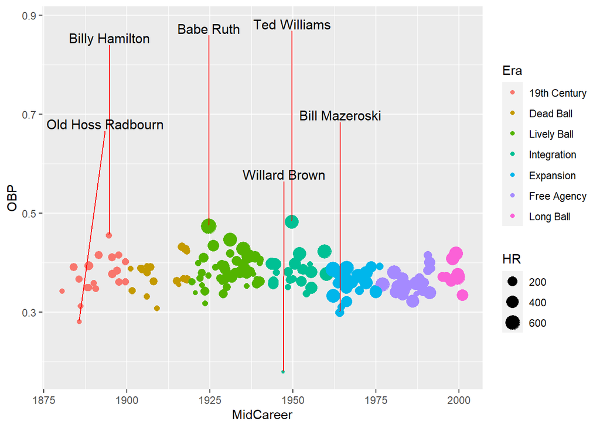

```r
p <- qplot(MidCareer, OBP, data = hof, color = Era, size = HR)
# Label speed outliers using geom_text_repel
r <- p + geom_text_repel(
  data = subset(hof, OBP > quantile(OBP, 0.75) + 1.5 * IQR(OBP) | OBP < quantile(OBP, 0.25) - 1.5 * IQR(OBP)),
  aes(x = MidCareer, y = OBP, label = Player),
  color = "#000000",
  size = 4,
  nudge_x = 0.2, nudge_y = 0.4,
  segment.color = "red",
)

print(r)
```

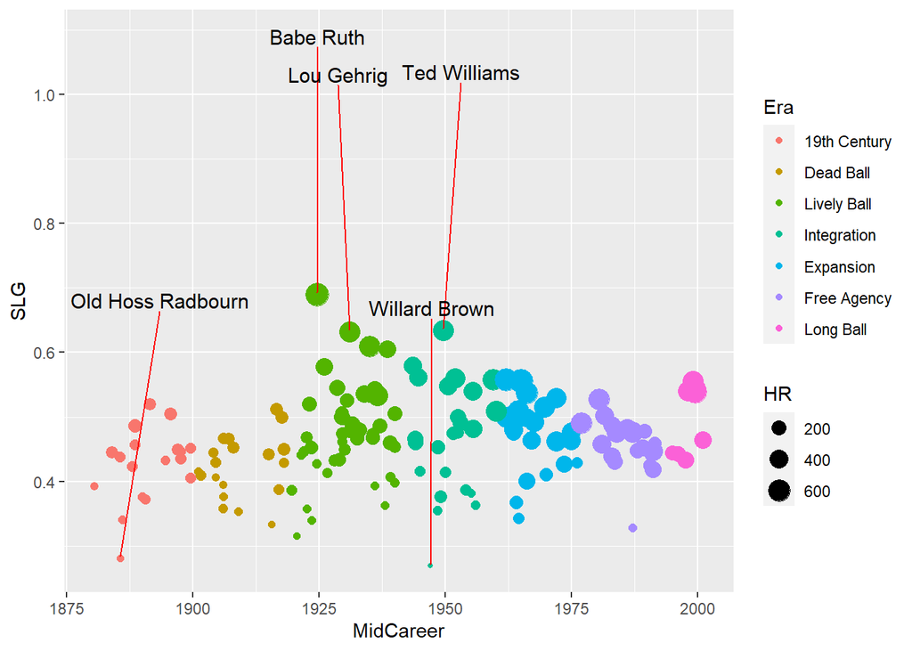

```r
p <- qplot(MidCareer, SLG, data = hof, color = Era, size = HR)
# Label speed outliers using geom_text_repel
r <- p + geom_text_repel(
  data = subset(hof, SLG > quantile(SLG, 0.75) + 1.5 * IQR(SLG) | SLG < quantile(SLG, 0.25) - 1.5 * IQR(SLG)),
  aes(x = MidCareer, y = SLG, label = Player),
  color = "#000000",
  size = 4,
  nudge_x = 0.2, nudge_y = 0.4,
  segment.color = "red",
)

print(r)
```

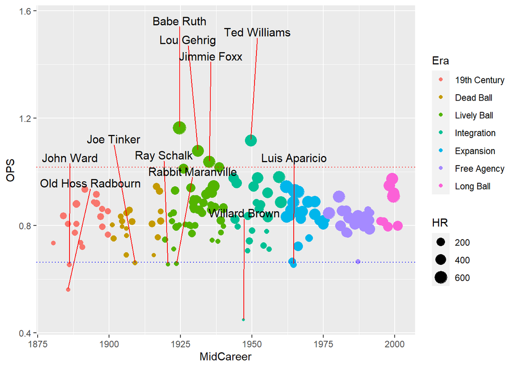

```r
p <- qplot(MidCareer, OPS, data = hof, color = Era, size = HR)
# Label speed outliers using geom_text_repel
r <- p + geom_text_repel(
  data = subset(hof, OPS > quantile(OPS, 0.75) + 1.5 * IQR(OPS) | OPS < quantile(OPS, 0.25) - 1.5 * IQR(OPS)),
  aes(x = MidCareer, y = OPS, label = Player),
  color = "#000000",
  size = 4,
  nudge_x = 0.2, nudge_y = 0.4,
  segment.color = "red",
)

# Add a horizontal line at the y-value corresponding to the OPS outlier threshold
r <- r + geom_hline(yintercept = quantile(hof$OPS, 0.75) + 1.5 * IQR(hof$OPS), color = "red", linetype = "dotted")
# Add a horizontal line at the y-value corresponding to the OPS outlier threshold
r <- r + geom_hline(yintercept = quantile(hof$OPS, 0.25) - 1.5 * IQR(hof$OPS), color = "blue", linetype = "dotted")



print(r)
```

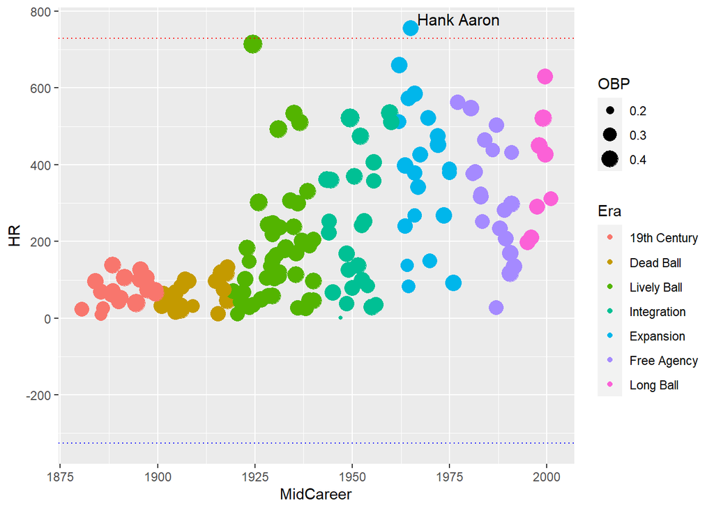

```r
p <- qplot(MidCareer, HR, data = hof, color = Era, size = OBP)
# Label speed outliers using geom_text_repel
r <- p + geom_text_repel(
  data = subset(hof, HR > quantile(HR, 0.75) + 1.5 * IQR(HR) | HR< quantile(HR, 0.25) - 1.5 * IQR(HR)),
  aes(x = MidCareer, y = HR, label = Player),
  color = "#000000",
  size = 4,
  nudge_x = 0.2, nudge_y = 0.4,
  segment.color = "red",
)

# Add a horizontal line at the y-value corresponding to the OPS outlier threshold
r <- r + geom_hline(yintercept = quantile(hof$HR, 0.75) + 1.5 * IQR(hof$HR), color = "red", linetype = "dotted")
# Add a horizontal line at the y-value corresponding to the OPS outlier threshold
r <- r + geom_hline(yintercept = quantile(hof$HR, 0.25) - 1.5 * IQR(hof$HR), color = "blue", linetype = "dotted")

print(r)
```

Now let’s make a histogram

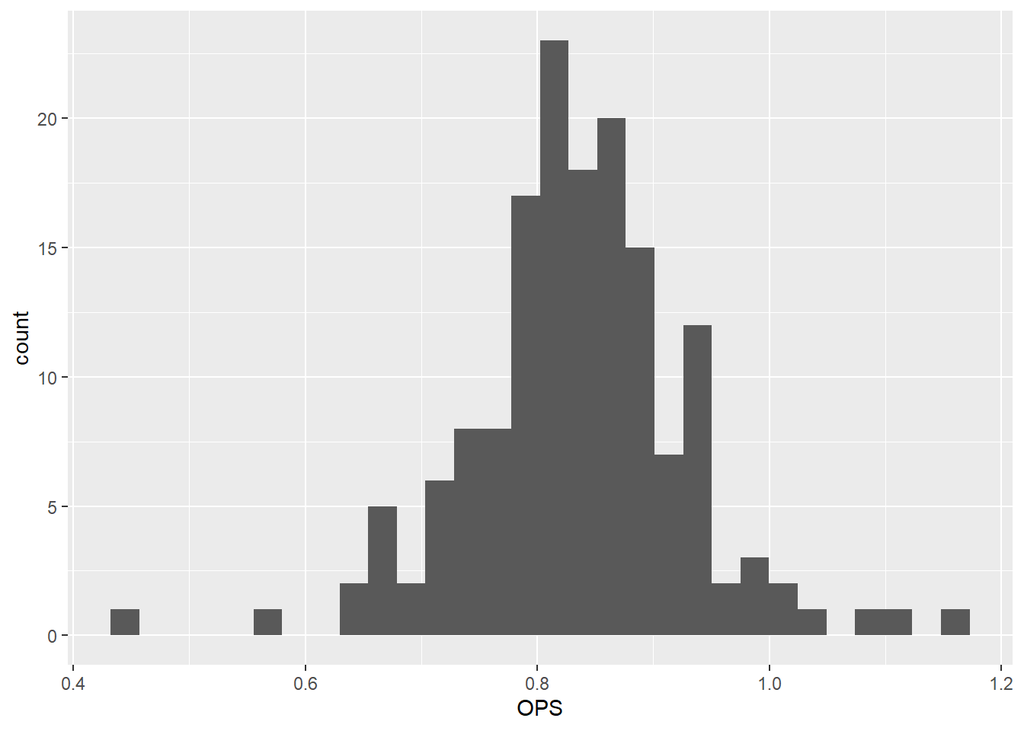

```r
ggplot(hof, aes(x=OPS)) +
  geom_histogram()
```

Let’s specify bin size

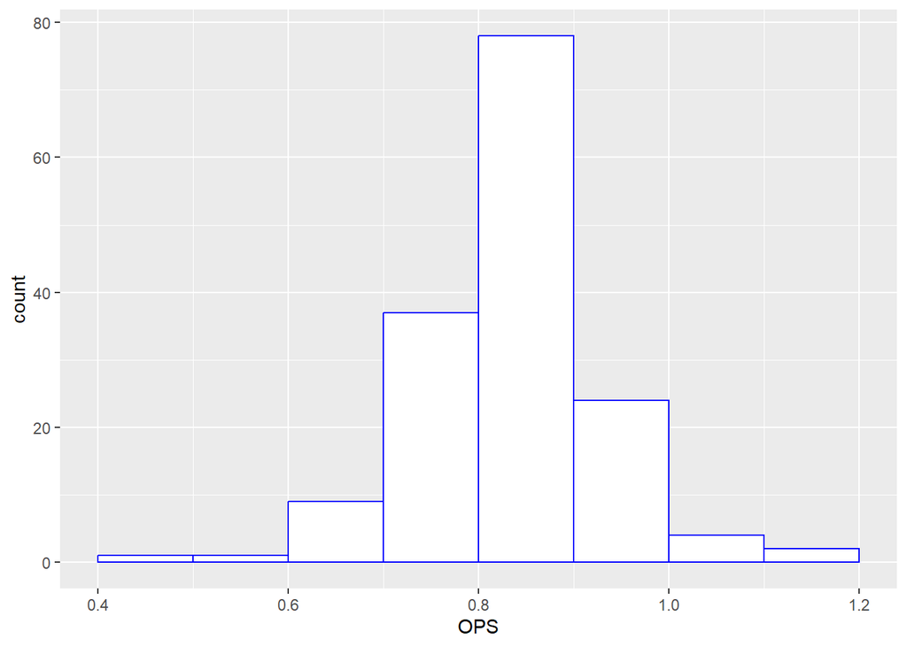

```r
ggplot(hof, aes(x=OPS)) +
  geom_histogram(breaks = seq(0.4, 1.2, by = 0.1),
                 color = "blue", fill = "white")
```

Chapter 3.5 Two Numeric Values, Scatter Plot with Smoothing

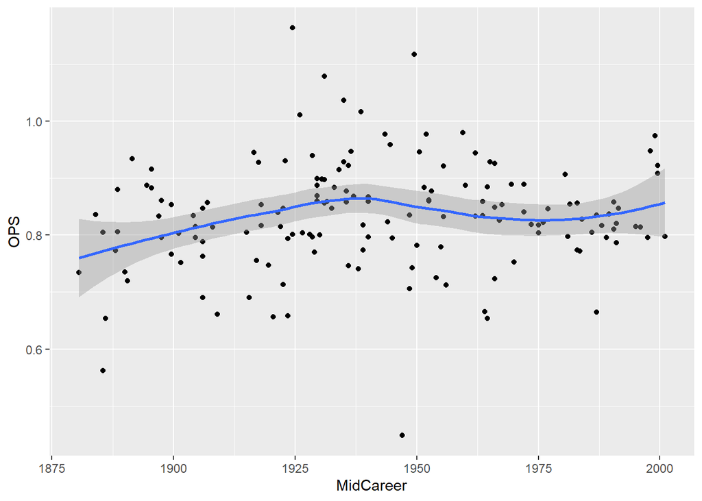

```r
ggplot(hof, aes(MidCareer, OPS)) +
  geom_point() +
  geom_smooth()
```

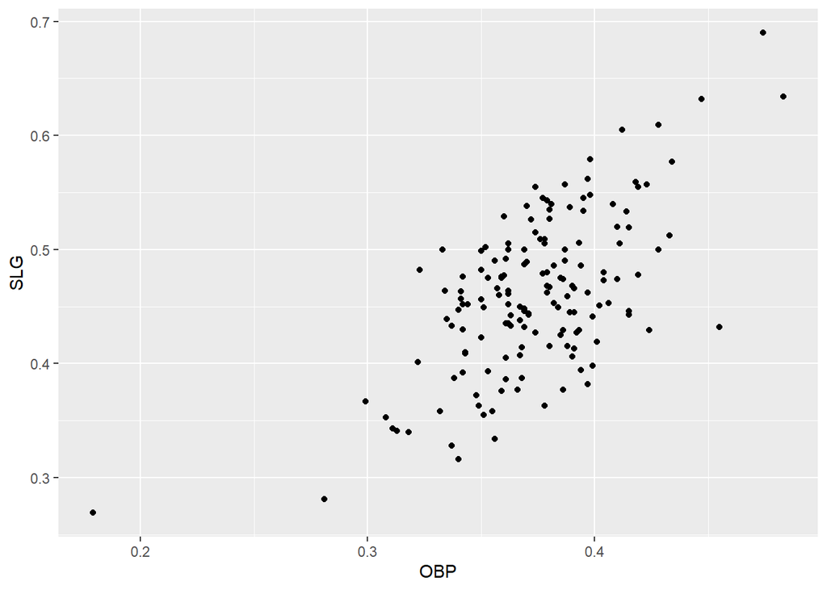

```r
(p <- ggplot(hof, aes(OBP,SLG)) + geom_point())
```

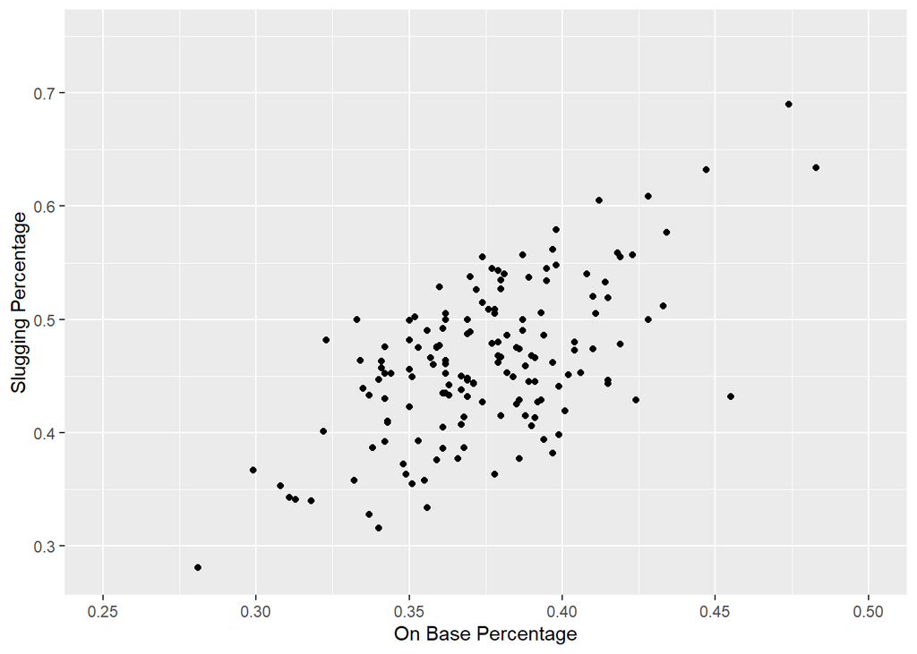

```r
lm_fit <- lm(SLG ~OBP, data = hof)

(p <- p +
    xlim(0.25, 0.50) + ylim(0.28, 0.75) +
    xlab("On Base Percentage") +
    ylab("Slugging Percentage"))
```

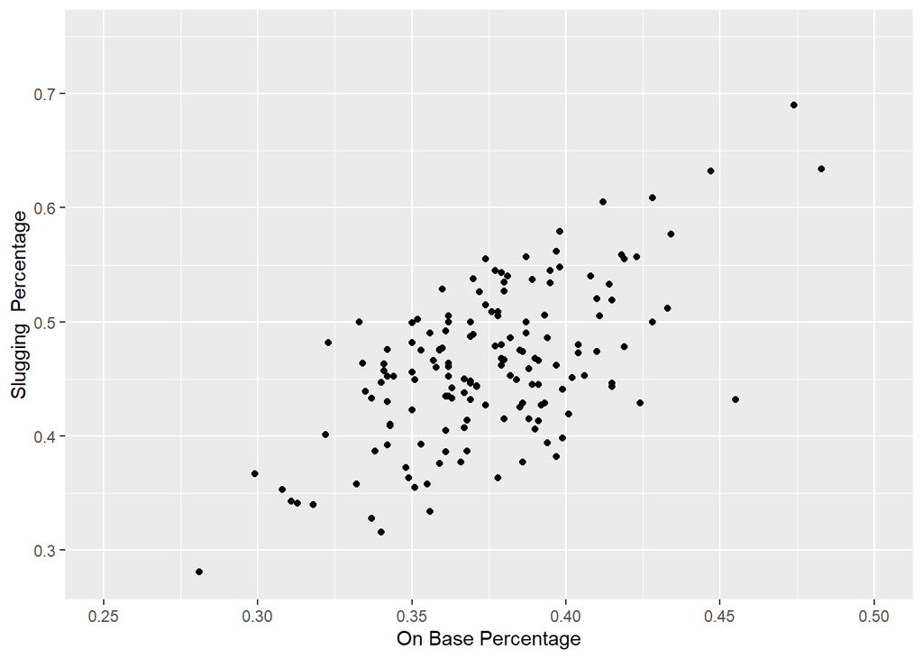

```r
#Alternatively we could change the limits and the labels by appealing directly to the scale_x_continuous() and scale_y_continuous() functions

p <- p +
  scale_x_continuous("On Base Percentage",
                     limits = c(0.25, 0.50)) +
  scale_y_continuous("Slugging  Percentage",
                     limits = c(0.28, 0.75))
p
```

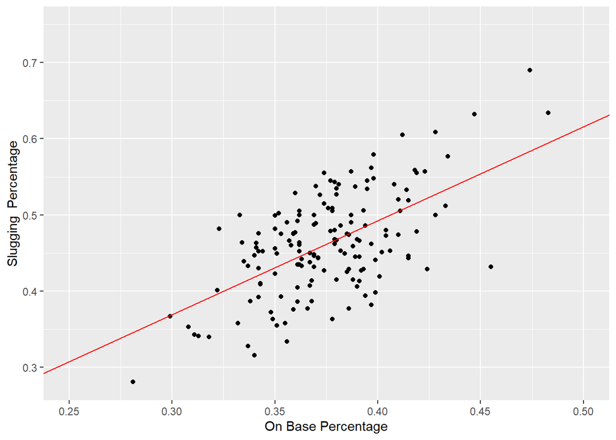

```r
q = p + geom_abline(intercept = coef(lm_fit)[1], slope = coef(lm_fit)[2], color="red")
q
```

Suppose we wanted to draw the function y=0.7-x on the graph:

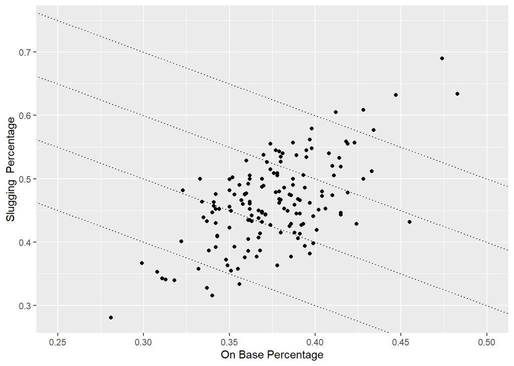

```r
(p <- p + geom_abline(slope = -1,
                      intercept = seq(0.7, 1, by=0.1),
                      color="black",
                      linetype = "dotted"))
```

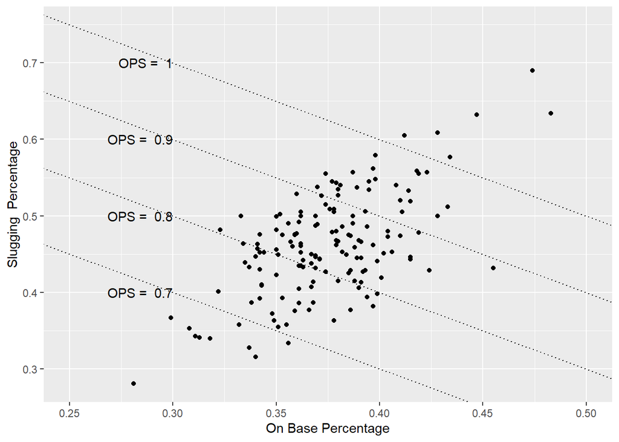

```r
#In our final iteration, we want to add labels to the lines showing the constant values of OPS
#First Let's create a dataframe which contains the coordiates
ops_labels <- tibble(
  OBP = rep(0.3, 4),
  SLG = seq(0.4, 0.7, by = 0.1),
  label = paste("OPS = ", OBP + SLG)
)

p + geom_text(data = ops_labels, hjust = "right",
              aes(label = label))
```

Ch 3.6.1 Parallel Strip Charts

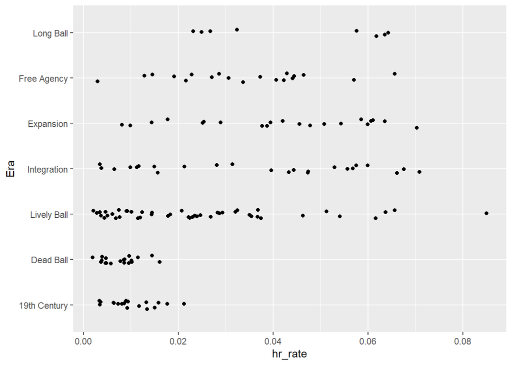

```r
#create a new column that's HR rate (home run per at bat) as opposed to total numbers
hof <- mutate(hof, hr_rate = HR/AB)

ggplot(hof, aes(hr_rate, Era)) +
  geom_jitter(height=0.1)
```

[figure not shown]

```r
r <- ggplot(hof, aes(Era, hr_rate)) +
  geom_boxplot(outlier.colour = "red") +
  coord_flip()

outliers <- subset(hof, hr_rate > quantile(hr_rate, 0.75) + 1.5 * IQR(hr_rate) | hr_rate < quantile(hr_rate, 0.25) - 1.5 * IQR(hr_rate))

r <- r + geom_text_repel(
  data = outliers,
  aes(x = hr_rate, y = Era, label = Player),  # Swap x and y aesthetics
  color = "#000000",
  size = 4,
  nudge_x = -0.2, nudge_y = 0.4,
  segment.color = "red",
)

print(r)
```

3.7 Comparing Ruth Aaron, Bons, and A-Rod Now we’ll start working with the Lahman data

```r
#First we need to adjust birthyear, MLB defines age season by the age of te player on June 30 of the season
#First let's create a function which will get us the correct age of each player
library(Lahman)
```

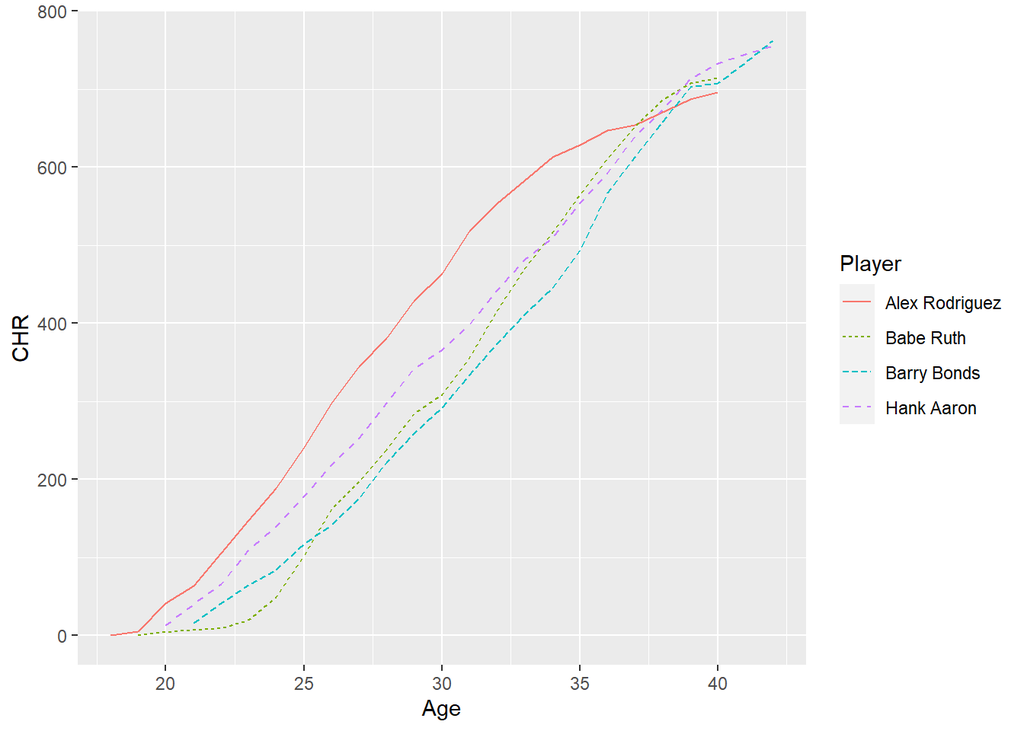

```r
Master <- Lahman::People #book said to use master.csv file, it looks like Lahman changed this to player.csv
Batting <- Lahman::Batting

get_birthyear <- function(Name) {
  Names <- unlist(strsplit(Name, " "))  #first we'll need to split the Name string into first and last name
  Master %>%
    filter(nameFirst == Names[1],
           nameLast == Names[2]) %>%
    mutate(birthyear = ifelse(birthMonth >= 7,
                              birthYear + 1, birthYear),
  Player = paste(nameFirst, nameLast)) %>%
  select(playerID, Player, birthyear)
}

PlayerInfo <- bind_rows(get_birthyear("Babe Ruth"),
                        get_birthyear("Hank Aaron"),
                        get_birthyear("Barry Bonds"),
                        get_birthyear("Alex Rodriguez"))

Batting %>%
  inner_join(PlayerInfo, by="playerID") %>%
  mutate(Age = yearID - birthyear) %>%
  select(Player, Age, HR) %>%
  group_by(Player)%>%
  mutate(CHR = cumsum(HR)) -> HRdata


#After the data cleaning let's construct a graph
lineplot <- ggplot(HRdata, aes(x=Age, y = CHR, linetype = Player)) +
  geom_line(aes(colour = Player))

print(lineplot)
```

Now it’s time to plot the Sammy Sosa vs Mark mcGuire Home Run Race

```r
fields <- read.csv("baseball_R/data/fields.csv")
data1998 <- read.csv("baseball_R/data/all1998.csv",
                     col.names = fields$Header)

#First thing we need to do after pulling in the data is to retrieve Mac and Sammy's ids
sosa_id <- Master %>%
  filter(nameFirst == "Sammy", nameLast == "Sosa") %>%
  pull(retroID)

mac_id <- Master %>%
  filter(nameFirst == "Mark", nameLast == "McGwire") %>%
  pull(retroID)


#now that we have their id's let's go to the play by play data
hr_race <- data1998 %>%
  filter(BAT_ID %in% c(sosa_id, mac_id))
```

3.8.2 Extracting the variables

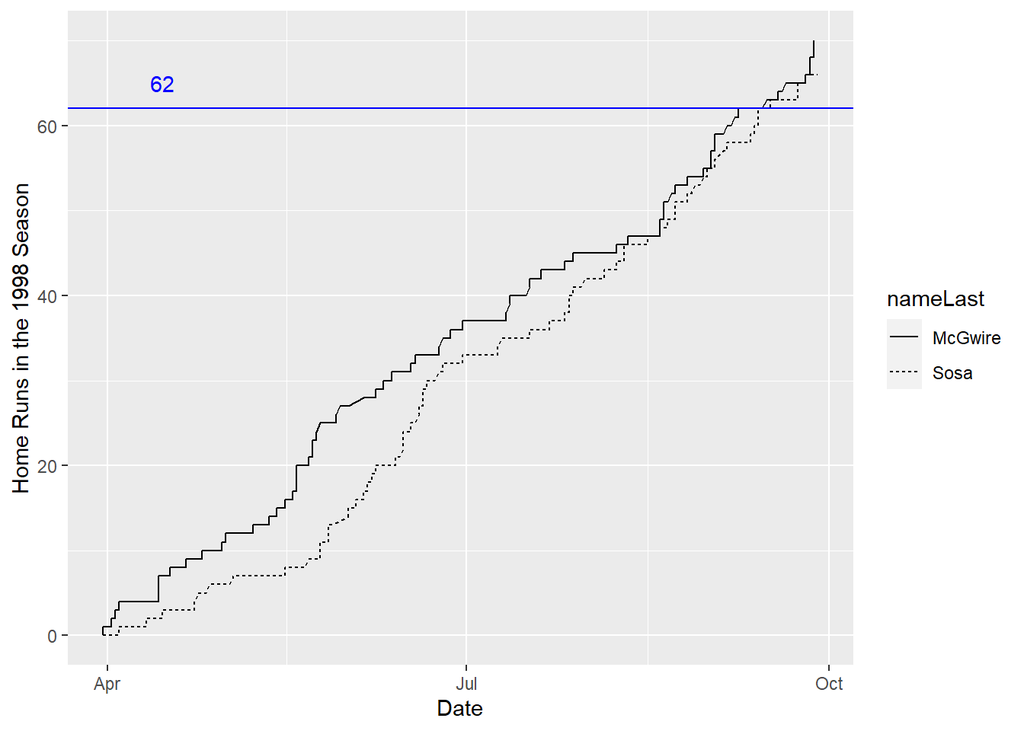

```r
library(lubridate)
cum_hr <- function(d) {
  d%>%
    mutate(Date = ymd(str_sub(GAME_ID, 4, 11))) %>%
    arrange(Date) %>%
    mutate(HR = ifelse(EVENT_CD ==23,1,0),
                       cumHR = cumsum(HR)) %>%
    select(Date, cumHR)
}

#Next, we will use map_df() function to itrate our new function cum_hr() twice, once for SOSAand once for McGwire's batting data, and obtaining a new data frame...hr_ytd
hr_ytd <- hr_race %>%
  split(pull(., BAT_ID)) %>%
  map_df(cum_hr, .id = "BAT_ID") %>%
  inner_join(Master, by = c("BAT_ID" = "retroID"))

#contructing the graph
ggplot(hr_ytd, aes(Date, cumHR, linetype=nameLast)) +
  geom_line() +
  geom_hline(yintercept=62, color="blue") +
  annotate("text", ymd("1998-04-15"), 65, label = "62", color="blue") +
  ylab("Home Runs in the 1998 Season")
```

Next let’s try the chapter 3 exercises 1. Hall of Fame Pitchers

```r
hofpitching <- read.csv("baseball_R/data/hofpitching.csv")

#BF variable is the number of batters faced in a pitcher's career.  Let's group the pitchers using the intervals designated in the book

hofpitching <- hofpitching %>%
  mutate(BF.group = cut(BF,
                        c(0, 10000, 15000, 20000, 30000),
                        labels = c("Less than 10000", "(10000, 14999)", ("15000, 19999"), "20000 or More")))
```

1.a Construct a Frequency Table

```r
#Let's do pitching era like we did with batting:
hofpitching <- hofpitching %>%
  mutate(MidCareer = (From + To) / 2,
         Era = cut(MidCareer,
                   breaks = c(1800, 1900, 1919, 1941, 1960, 1976, 1993, 2050),
                   labels = c("19th Century", "Dead Ball", "Lively Ball", "Integration", "Expansion", "Free Agency", "Long Ball")))

hofpitching_bfgroupfreqtable <- hofpitching %>%
  group_by(BF.group) %>%
  summarise(
    Frequency = n(),
    WAR = sum(WAR),
    SO = sum(SO),
    BB = sum(BB),
    HBP = sum(HBP),
    CG = sum(CG)
  )

hofpitching_yearfreqtable <- hofpitching %>%
  group_by(Era) %>%
  summarise(
    Frequency = n(),
    WAR = sum(WAR),
    SO = sum(SO),
    BB = sum(BB),
    HBP = sum(HBP),
    CG = sum(CG)
  )
```

Construct the histogram

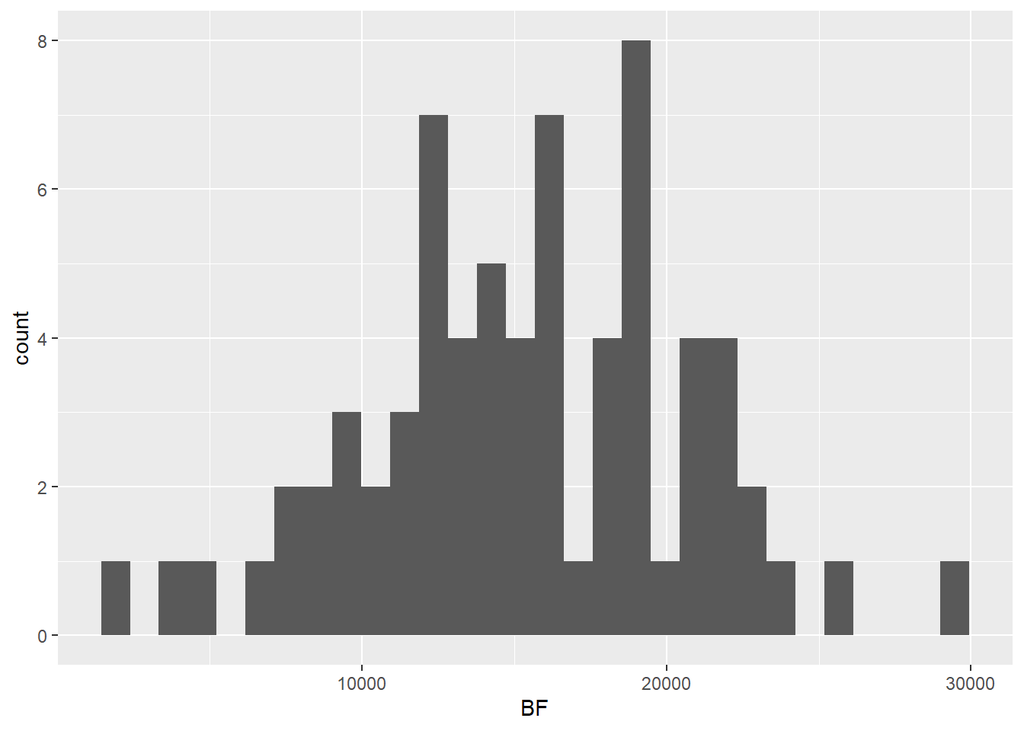

```r
ggplot(hofpitching, aes(x=BF)) +
  geom_histogram()
```

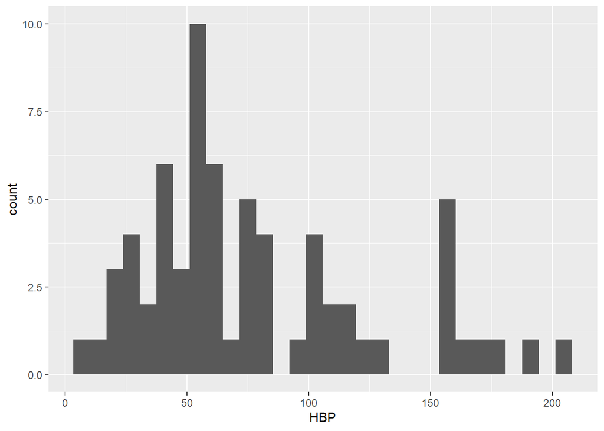

```r
ggplot(hofpitching, aes(x=HBP)) +
  geom_histogram()
```

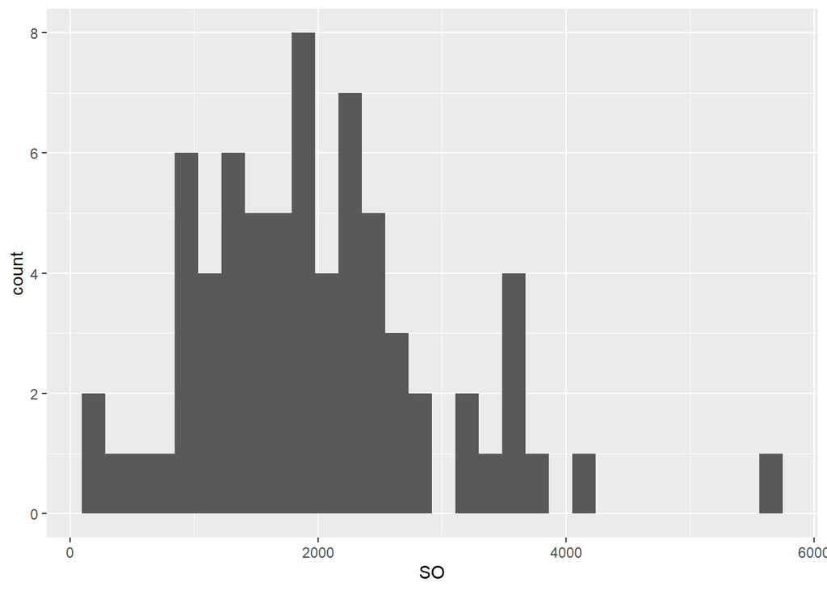

```r
ggplot(hofpitching, aes(x=SO)) +
  geom_histogram()
```

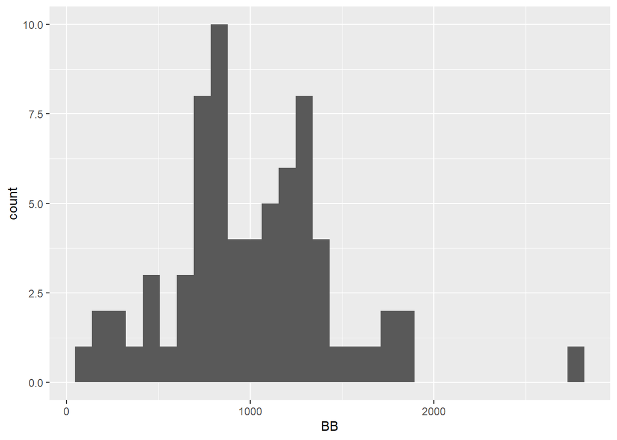

```r
ggplot(hofpitching, aes(x=BB)) +
  geom_histogram()
```

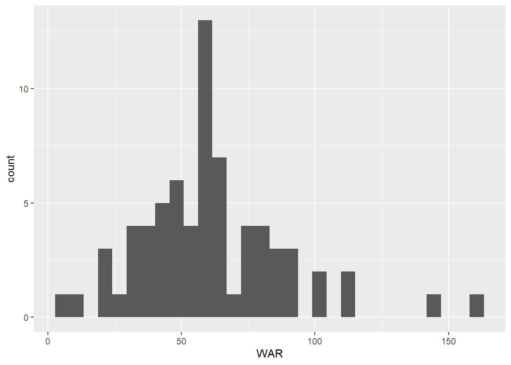

```r
ggplot(hofpitching, aes(x=WAR)) +
  geom_histogram()
```

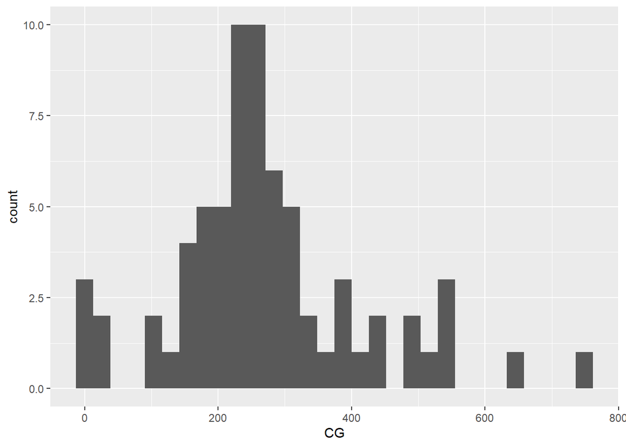

```r
ggplot(hofpitching, aes(x=CG)) +
  geom_histogram()
```

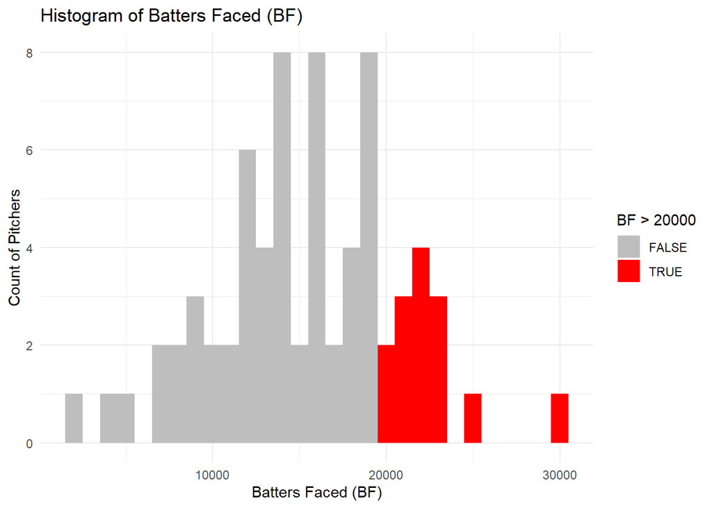

```r
ggplot(hofpitching, aes(x = BF, fill = BF > 20000)) +
  geom_histogram(binwidth = 1000) +
  scale_fill_manual(values = c("FALSE" = "gray", "TRUE" = "red")) +
  ylab("Count of Pitchers") +
  xlab("Batters Faced (BF)") +
  ggtitle("Histogram of Batters Faced (BF)") +
  theme_minimal()
```

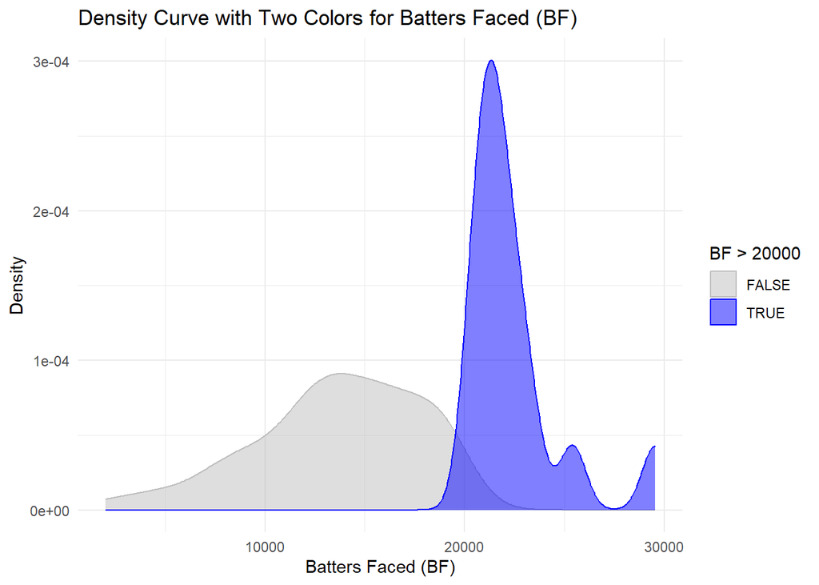

```r
ggplot(hofpitching, aes(x = BF)) +
  geom_density(aes(fill = BF > 20000, color = BF > 20000), alpha = 0.5) +
  scale_fill_manual(values = c("FALSE" = "gray", "TRUE" = "blue")) +
  scale_color_manual(values = c("FALSE" = "gray", "TRUE" = "blue")) +
  ylab("Density") +
  xlab("Batters Faced (BF)") +
  ggtitle("Density Curve with Two Colors for Batters Faced (BF)") +
  theme_minimal()
```

Now let’s do a bar graph by BF.group

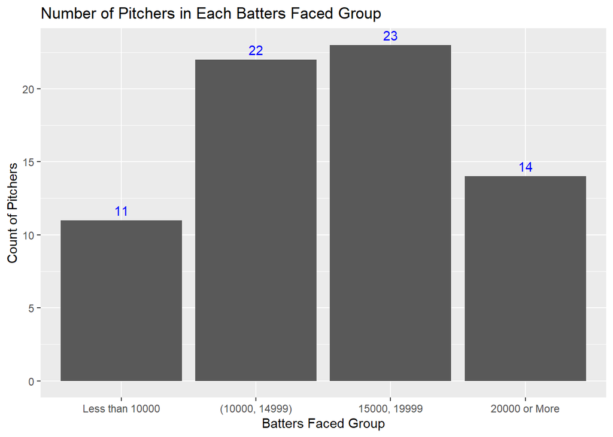

```r
ggplot(hofpitching, aes(BF.group)) +
  geom_bar() +
  geom_text(stat = "count", aes(label = after_stat(count), vjust=-0.5), color="blue") +
  ylab("Count of Pitchers") +
  xlab("Batters Faced Group") +
  ggtitle("Number of Pitchers in Each Batters Faced Group")
```